[figure not shown]

NHSBorders

```r
library(tidyverse)
library(janitor)
```

# The Brief from NHS Borders

In order to help inform the planning for provision of cancer treatment services in NHS Borders, we would like to gain better understanding of the incidence of cancer in NHS Borders.

## My Methodology

To best assist NHS Borders in their planning for provision of cancer treatment services I decided to focus on three main areas for analysis:

- How does the total cancer incidence rate in Borders compare with the Scottish average?
- What are the most prevalent cancer sites in NHS Borders?
- Of those most prevalent, is there any trends in age groups that could give further insight into the provision of cancer treatments?

Through these three questions my aim is to provide insight into the occurence of cancer in their geographical area and how they may wish plan their treatment accordingly.

```r
cancer_5yr_data <- read_csv(here::here("5yr_incidence_health_board.csv")) %>%
  clean_names()

total_incidences_data <- read_csv(here::here("Total_incidences_health_board.csv")) %>%
  clean_names()
```

## Data Wrangling

```r
borders_cancer_5yr <- cancer_5yr_data %>%
  filter(hb == "S08000016")

total_incidences_borders <- total_incidences_data %>%
  filter(hb == "S08000016")
```

```r
# bind two data sets for dodged bar plot
rest_scotland_cancer <- total_incidences_data %>%
  filter(cancer_site == "All cancer types" & hb != "S08000016") %>%
  filter(sex == "All") %>%
  group_by(year) %>%
  summarise(incidences_all_ages = mean(incidences_all_ages))

borders_cancer_all <- total_incidences_borders %>%
  filter(cancer_site == "All cancer types") %>%
  filter(sex == "All")

cancer_bind_data <- bind_rows(rest_scotland_cancer, borders_cancer_all)

# if_else to assign a borders/scotland tag to each cancer incidence
health_board <- cancer_bind_data %>%
  mutate(health_board = if_else(incidences_all_ages < 1000, "Borders", "Scotland"), .after = 1)
```

## How does the total cancer incidence rate in Borders compare with the Scottish average?

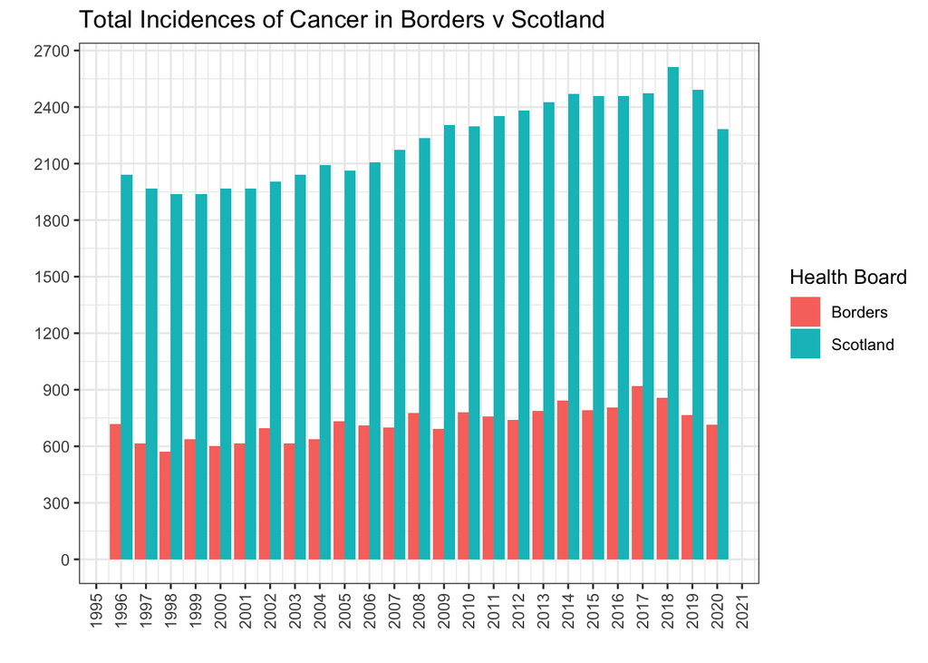

```r
dodged_cancer_plot <- health_board %>%
  ggplot(aes(x = year, y = incidences_all_ages, fill = health_board)) +
  geom_col(position = "dodge") +
  scale_x_continuous(n.breaks = 24) +
  scale_y_continuous(n.breaks = 10) +
  theme_bw() +
  theme(axis.text.x=element_text(angle = 90, vjust = 0.5)) +
  labs(title = "Total Incidences of Cancer in Borders v Scotland",
       x = "",
       y = "",
       fill = "Health Board")

dodged_cancer_plot
```

At first viewing we can see that cancer incidences in NHS Borders appear to follow the greater trend across the rest of the health boards in Scotland. This could be seen as an indicator that NHS Borders are at least screening an appropriate amount versus the country as a whole. We can see the dip from 2019 onwards, most likely due to the decrease in cancer provisions during the COVID-19 pandemic.

What NHS Borders can take from this is that cancer incidences have decreased steadily over the last two years and we would expect to see a sharp rise over the next 1-3 years as a result of the backlog and yet-to-be-detected cancer cases. They should not be alarmed at the trend moving in this direction as it could be considered as simply returning to a usual rate of incidence (regressing to the mean)

## What are he Most Prevalent Cancer Sites in the NHS Borders?

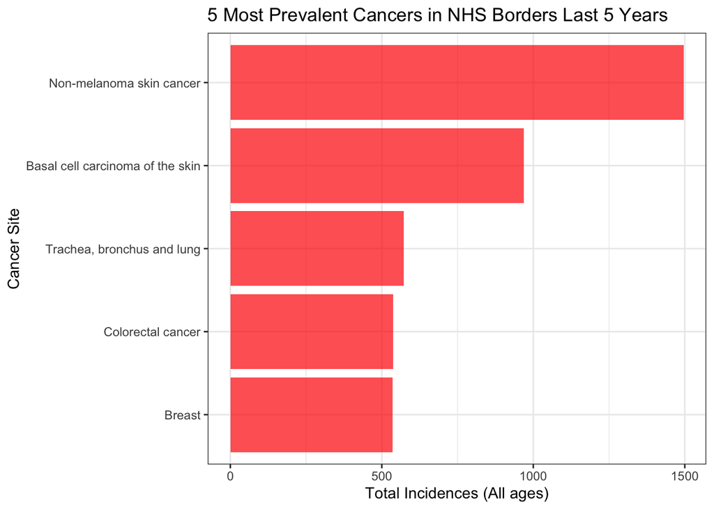

```r
top_five_prevalent_cancers <- borders_cancer_5yr %>%
  select(cancer_site, sex, incidences_all_ages) %>%
  filter(sex == "All" & cancer_site != "All cancer types") %>%
  slice_max(incidences_all_ages, n = 5) %>%
  mutate(cancer_type = fct_reorder(cancer_site, incidences_all_ages)) %>%
  ggplot(aes(x = cancer_type , y = incidences_all_ages)) +
  geom_col(fill = "red", alpha = 0.7) +
  coord_flip() +
  labs(title = "5 Most Prevalent Cancers in NHS Borders Last 5 Years",
       x = "Cancer Site",
       y = "Total Incidences (All ages)") +
  theme_bw()

top_five_prevalent_cancers
```

To assist NHS Borders in deciding where their funding could be best aimed, in terms of cancer screening/treatments, I found the 5 most prevalent cancer sites in patients from NHS Borders. Often the best solution to lowering cancer rates is in early detection and screening. The top 5 cancer sites across the Borders were:

- Non-Melanoma Skin Cancer
- Basil Cell Carcinoma of the Skin
- Trachea, Bronchus and Lung
- Colorectal Cancer
- Breast

These give an immediate actionable insight for the NHS Borders, as we can clearly see what cancer sites are driving their incidence numbers and what they could decide to plan extra provisions for in the treatment of these cancers.

# Age Group Spread of Top 5 Cancers NHS Borders

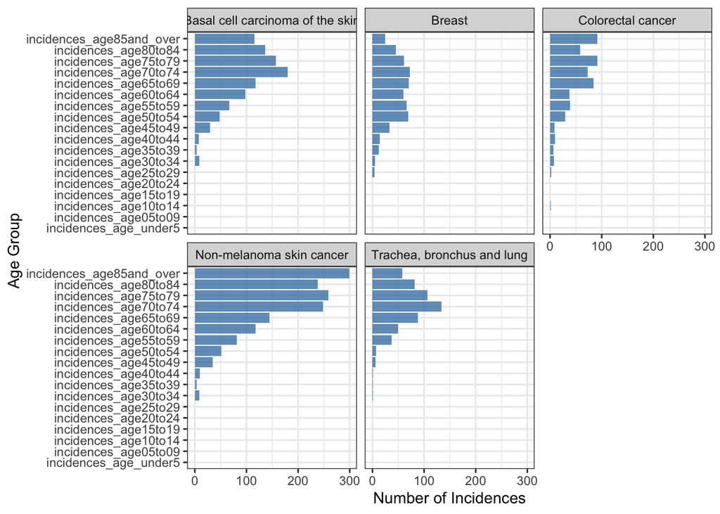

```r
age_top5_cancers <- borders_cancer_5yr %>%
  select(cancer_site, sex, incidences_age_under5:incidences_age85and_over) %>%
  rename(incidences_age05to09 = incidences_age5to9) %>%
  filter(cancer_site %in% c("Non-melanoma skin cancer", "Basal cell carcinoma of the skin",
                            "Trachea, bronchus and lung", "Colorectal cancer",
                            "Breast") & sex == "All") %>%
  pivot_longer(cols = incidences_age_under5:incidences_age85and_over,
               names_to = "age_group", values_to = "count") %>%
  ggplot(aes(x = age_group, y = count)) +
  geom_col(fill = "steel blue", alpha = 0.8) +
  coord_flip() +
  facet_wrap(~cancer_site) +
  theme_bw() +
  labs(x = "Age Group",
       y = "Number of Incidences")

age_top5_cancers
```

Here we can observe the spread of age groups in the 5 most prevalent cancer sites across the Borders to see if there are any apparent trends or areas the NHS Borders could focus their provision planning on.

For Breast Cancer the incidences take a leap up in the 50-54 age group and stays roughly uniform until 80-84. This could be linked to breast screening occurring towards the age of 50 (something NHS Borders could confirm) However, an actionable insight could be to introduce earlier breast screening to improve early detection.